# Получение данных по ценам из RTPI

Салихов Марсель (marcel.salikhov@gmail.com)

8 апреля, 2021

## Обзор

RTPI - это база данных по ценам на отдельные потребительские товары, которая формируется за счет веб-скрейпинга Интернет-сайтов крупных розничных сетей обновляется в реальном времени. Описание RTPI представлено в публикации (Isakov 2021). Для доступа к данным вам необходимо обратиться к разрабочикам и получить токен.

[Примеры](https://colab.research.google.com/drive/1qqTe8uUwWY4j7-C67UdqwDDDVYPXdUWg?usp=sharing), представленные авторами пакета для получения и обработки данных данных, написаны на Python.

## Получение данных

Набор функций, представленный в [`functions.R`](https://raw.githubusercontent.com/quantviews/RTPI/main/functions.R) позволяет получить доступ к данным RTPI из R, не обращаясь к Python напрямую. Таким образом, если вы знаете R, но не знаете Python, это облегчит доступ к данным.

В настоящее время в наборе представлено несколько основных функций, которые позволяют решить большинство типовых задач.

Получим данные весов для ИПЦ Росстата c помощью функции `rtpi_rosstat_weight`. Функция не требует никаких входных параметров, а возвращает таблицу с весами. Это официальные веса, которые используются Росстатом для расчета индекса потребительских цен. Столбец `rosstat_id` представляет собой идентификатор продуктовых категорий.

```r
# token <- '' # необходимо иметь токен
weights <- rtpi_rosstat_weight()
```

|  | rosstat_id | rosstat_name | year | rosstat_weight |
| --- | --- | --- | --- | --- |
| 1 | 105 | Фарш мясной, кг | 2020 | 0.00608 |
| 2 | 106 | Пельмени, манты, равиоли, кг | 2020 | 0.00592 |
| 3 | 107 | Печень говяжья, кг | 2020 | 0.00146 |
| 4 | 111 | Говядина (кроме бескостного мяса), кг | 2020 | 0.00687 |
| 5 | 112 | Говядина бескостная, кг | 2020 | 0.00386 |
| 6 | 113 | Свинина (кроме бескостного мяса), кг | 2020 | 0.00767 |
| 7 | 114 | Куры охлажденные и мороженые, кг | 2020 | 0.01026 |
| 8 | 115 | Окорочка куриные, кг | 2020 | 0.00462 |
| 9 | 116 | Баранина (кроме бескостного мяса), кг | 2020 | 0.0015 |
| 10 | 117 | Свинина бескостная, кг | 2020 | 0.0065 |

[output cut: 510 more lines]

используем тот же пример, с линолеумом (`rosstat_id = 7411`), который представляет в примере разработчиков для Python.

```r
rosstat_id = 7411
pg <- rtpi_price_page_rosstat(rosstat_id)
datatable(pg)
```

|  | web_price_id | price_name | price_url | date_add | date_last_crawl | date_last_in_stock | rosstat_id | contributor_id | store_id |
| --- | --- | --- | --- | --- | --- | --- | --- | --- | --- |
| 1 | 201102 | https://leroymerlin.ru/product/linoleum-dub-panamskiy-32-klass-4-m-82319646/ | https://leroymerlin.ru/product/linoleum-dub-panamskiy-32-klass-4-m-82319646/ | 2020-06-29T14:38:19.41 | 2021-03-02T15:00:36.69 | 2021-03-02T15:00:36.69 | 7411 | 1 | 73 |
| 2 | 201064 | https://leroymerlin.ru/product/linoleum-dub-korolevskiy-31-klass-3-m-82312402/ | https://leroymerlin.ru/product/linoleum-dub-korolevskiy-31-klass-3-m-82312402/ | 2020-06-29T14:38:19.41 | 2021-03-02T15:00:47.36 | 2021-03-02T15:00:47.36 | 7411 | 1 | 73 |
| 3 | 201059 | https://leroymerlin.ru/product/linoleum-dub-sprinfild-31-klass-3-5-m-14297044/ | https://leroymerlin.ru/product/linoleum-dub-sprinfild-31-klass-3-5-m-14297044/ | 2020-06-29T14:38:15.81 | 2021-03-02T15:00:57.883 | 2021-03-02T15:00:57.883 | 7411 | 1 | 73 |
| 4 | 201225 | https://leroymerlin.ru/product/linoleum-sirius-sonata-70-32-klass-3-m-18621788/ | https://leroymerlin.ru/product/linoleum-sirius-sonata-70-32-klass-3-m-18621788/ | 2020-06-29T14:38:15.81 | 2021-03-02T15:00:17.113 | 2021-03-02T15:00:17.113 | 7411 | 1 | 73 |
| 5 | 201281 | https://leroymerlin.ru/product/linoleum-tuluza-32-klass-2-5-m-82361152/ | https://leroymerlin.ru/product/linoleum-tuluza-32-klass-2-5-m-82361152/ | 2020-06-29T14:38:19.41 | 2021-03-02T15:00:28.69 | 2021-03-02T15:00:28.69 | 7411 | 1 | 73 |
| 6 | 201086 | https://leroymerlin.ru/product/linoleum-dub-katon-31-klass-4-m-82362484/ | https://leroymerlin.ru/product/linoleum-dub-katon-31-klass-4-m-82362484/ | 2020-06-29T14:38:19.41 | 2021-03-02T15:00:40.043 | 2021-03-02T15:00:40.043 | 7411 | 1 | 73 |
| 7 | 201154 | https://leroymerlin.ru/product/linoleum-tempo-dub-reyner-33-klass-4-m-18618546/ | https://leroymerlin.ru/product/linoleum-tempo-dub-reyner-33-klass-4-m-18618546/ | 2020-06-29T14:38:15.81 | 2021-03-28T14:09:18.857 | 2021-03-28T14:09:18.857 | 7411 | 1 | 73 |
| 8 | 201228 | https://leroymerlin.ru/product/linoleum-artens-dub-norvezhskiy-31-klass-1-5-m-18569801/ | https://leroymerlin.ru/product/linoleum-artens-dub-norvezhskiy-31-klass-1-5-m-18569801/ | 2020-06-29T14:38:15.81 | 2021-03-02T15:00:23.893 | 2021-03-02T15:00:23.893 | 7411 | 1 | 73 |
| 9 | 201283 | https://leroymerlin.ru/product/linoleum-dub-oksford-23-klass-1-5-m-16377451/ | https://leroymerlin.ru/product/linoleum-dub-oksford-23-klass-1-5-m-16377451/ | 2020-06-29T14:38:19.41 | 2021-03-02T15:00:43.397 | 2021-03-02T15:00:43.397 | 7411 | 1 | 73 |
| 10 | 201200 | https://leroymerlin.ru/product/linoleum-artens-dub-francuzskiy-31-klass-3-5-m-18569908/ | https://leroymerlin.ru/product/linoleum-artens-dub-francuzskiy-31-klass-3-5-m-18569908/ | 2020-06-29T14:38:15.81 | 2021-03-02T15:00:20.47 | 2021-03-02T15:00:20.47 | 7411 | 1 | 73 |

[output cut: 304 more lines]

Таблица `pg` содержит все товары, которые содержатся в базе и которое размечены, как относящиеся к категории `rosstat = 7411`, то есть к линолеуму. Обратите внимание, что скорее всего, это не все линолеумы, которые есть в базе. Это просто те, которые были размечены, то есть у которых есть ненулевой параметр `rosstat_id`ю

В данном случае таблице `pg` содержится 314 строк. Получим информацию о названии каждого продукта с помощью функции `get_prods_names_by_id`. Функция принимает вектор из идентификаторов продуктов (`web_price_id`) и возвращает таблицу.

```r
web_price_id  <- pg$web_price_id
prods <- get_prods_names_by_id(web_price_id)
datatable(prods)
```

|  | web_price_id | product_name | contributor_id | moment |
| --- | --- | --- | --- | --- |
| 1 | 201059 | Линолеум «Дуб Спринфилд» 31 класс 3.5 м | 1 | 2021-03-19T16:20:05.443 |
| 2 | 201064 | Линолеум «Дуб Королевский» 31 класс 3 м | 1 | 2021-03-19T16:20:05.443 |
| 3 | 201065 | Линолеум «Дуб Королевский» 31 класс 4 м | 1 | 2021-03-19T16:20:05.443 |
| 4 | 201066 | Линолеум «Долорес» 31 класс 4 м | 1 | 2021-03-19T16:20:05.443 |
| 5 | 201067 | Линолеум «Дуб Гренланд» 31 класс 3 м | 1 | 2021-03-19T16:20:05.443 |
| 6 | 201071 | Линолеум «Сириус Соната 33» 32 класс 4 м | 1 | 2021-03-19T16:20:05.443 |
| 7 | 201075 | Линолеум «Дуб Каро» 31 класс 1.5 м | 1 | 2021-03-19T16:20:05.443 |
| 8 | 201076 | Линолеум «Дуб Каро» 31 класс 2.5 м | 1 | 2021-03-19T16:20:05.443 |
| 9 | 201077 | Линолеум «Дуб Каро» 31 класс 3.5 м | 1 | 2021-03-19T16:20:05.443 |
| 10 | 201078 | Линолеум «Парадокс Дуб сапфир» 32 класс 3.5 м | 1 | 2021-03-19T16:20:05.443 |

[output cut: 278 more lines]

Обратите, что мы смогли идентифицировать названия 288 столбцов, то есть меньше, чем содержится в таблице `pg`.

Теперь получим информацию по ценам на линолеумы, по которым есть названия. Для этого надо использовать функцию `rtpi_price_history`. Входным параметром является также вектор из `web_price_id`.

```r
web_price_ids <- prods$web_price_id
prices <- rtpi_price_history(web_price_ids) # price history of items
prices <- widen_price_history(prices)
```

В таблице `prices` в колонках находятся отдельные товары (названия столбцов - `web_price_id`). По строкам - даты. База данных устроена таким образом, что запись информации о ценах происходит, если произошло изменение цен. В противном случае (то есть, если цены не изменились), то ничего не записывается. В таблице `prices` в те дни, в которые не были зафиксировано изменение цен будет стоять `NA`. Вспомогательная функция `widen_price_history` заполнит это `NA` предsщими значениями, если они есть. Это облегчит, к примеру, построение графиков.

## Построение графика

К примеру, мы хотим построить график по ценам на линолеумы, которые получили ранее.

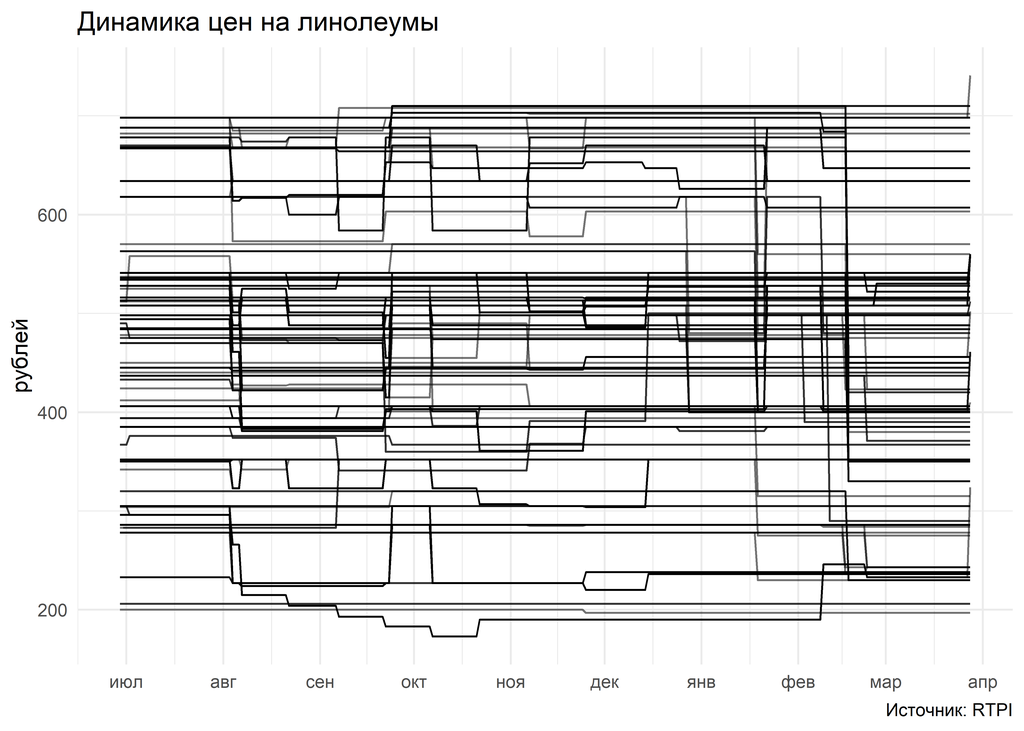

```r
library(ggplot2)
theme_set(theme_minimal())
# преобразуем таблицу в длиный (long) формат
prices_long <- tidyr::pivot_longer(prices, -1, names_to = "web_price_id", values_to = "price")
prices_long <- merge(prices_long, prods, by = "web_price_id")

p <- ggplot(prices_long, aes(x = date_observe, y = price, group = web_price_id))
p <- p + geom_line(aes(alpha = 0.05)) + xlab(NULL) + ylab('рублей')+ theme(legend.position = "none")
p <- p + scale_x_date(date_breaks = "1 month", date_labels = '%b')
p + labs(title = 'Динамика цен на линолеумы', caption = 'Источник: RTPI')
```

Isakov, Latypov, A. 2021. “Hard Numbers: Open Consumer Price Database.” *Russian Journal of Money and Finance* 80 (1): 104–19.